# Replication Code: A Replication of *Measuring and Explaining Political Sophistication through Textual Complexity* (Benoit et al., 2019)

PPOL 6801: Text as Data: Computational Linguistics

Author

Wendy Shi & Maria Bartlett

Published

February 18, 2025

### Set-up

```r
# clear global environment
rm(list = ls())

# set seed
set.seed(12345)

# provide instruction for how to install user-written packages
#devtools::install_github("quanteda/spacyr", build_vignettes = FALSE)
#library(spacyr)
#spacy_install()
#spacy_initialize()
#devtools::install_github("kbenoit/sophistication")

# load packages
library(tidyverse)
library(spacyr)
library(sophistication)
library(BradleyTerry2)
library(modelsummary)
library(quanteda)
library(quanteda.textstats)
library(assertr)
library(DT)
library(randomForest)
library(kableExtra)

# set processing/display options
options(mc.cores = parallel::detectCores())
options(dplyr.summarise.inform = FALSE)
options(warn = -1)

# set relative paths
root       <- file.path(getwd() %>% dirname())
author_rep <- file.path(root,"02_DataverseMaterials","dataverse_files")
```

### Step 1. Load Crowdsourced data

As directly quoted from `Codebook.pdf` in Benoit, Munger, and Spirling’s replication package:

“These are the coded snippet comparisons that were downloaded from Crowdflower after the crowd-sourced job was completed.”

Key variables (definitions quoted directly from `Codebook.pdf`):

- `docID1`: “The document ID for the text from which first snippet was taken, e.g.”Bush-2005””
- `snippetID1`: “A unique numeric snippet identifier for snippet 1”
- `text1:` “The plain text of snippet 1”
- same `docID2`,`snippedID2`, `text2` for snippet 2
- `X_golden`: “a logical value (true or false) indicating whether the snippet pair was a”gold” question for which we supplied an answer”
- `screener`: “a logical value TRUE indicating whether the question was a”screener” (a special gold question with embedded instructions to the coder as to how to answer the task) or blank if the question was not a screener.”
- `X_id`: “a unique numeric identifier for the answer, assigned by Crowdflower (e.g. 2025513496)”
- `X_missed`: “a Boolean (true or blank) indicating whether the crowd worker missed a gold question”
- `X_tainted`: “a Boolean (true or false) indicating whether the answer was”tainted” because the worker missed too many screening questions. Because we excluded tainted answers, in our data, all values of this variable are false.”
- `X_trust`: “the”trust” score for the respondent, as computed by Crowdflower. Our minimum was 0.60 and our mean answer had a trust value of around 0.86.”
- `X_worker_id`: “a unique numeric identifier for the worker, e.g. 34616922”
- `easier`: “1 or 2, indicating which snippet was answered as being easier by the worker. This is the core data we used in scoring the snippets.”

```r
# NOTE: based on original code; added tidyverse + verification updates
# ----
# load human-coded data of SOTU passages from CrowdFlower
allsentences <- rbind(read.csv(file.path(author_rep,"CF_output_f999866.csv"), stringsAsFactors = FALSE),
                      read.csv(file.path(author_rep,"CF_output_f952737.csv"), stringsAsFactors = FALSE)) %>%
  # confirm file is unique on id level
  verify(anyDuplicated(select(.,c(X_id))) == 0) %>%
  # check dimensions of data
  verify(nrow(.) == 27807 & ncol(.) == 25) %>%
  # confirm all tainted responses have been removed, per codebook
  verify(X_tainted == "false")

# NOTE: new to MB + WS replication
# ---
# output a few examples of text comparisons
allsentences %>%
  select(X_id,X_worker_id,snippetid1,docid1,text1,snippetid2,docid2,text2,easier) %>%
  distinct() %>%
  slice_head(n = 5) %>%
  datatable()
```

|  | X_id | X_worker_id | snippetid1 | docid1 | text1 | snippetid2 | docid2 | text2 | easier |
| --- | --- | --- | --- | --- | --- | --- | --- | --- | --- |
| 1 | 2442259130 | 42134019 | 3400300 | Carter-1981 | Under my Executive Order 12044, we required agencies to analyze the costs of their major new rules and consider alternative approaches-such as performance standards and voluntary codes-that may make r… | 6000054 | Bush-2006 | We also show compassion abroad because regions overwhelmed by poverty, corruption, and despair are sources of terrorism and organized crime and human trafficking and the drug trade. In recent years, y… | 1 |
| 2 | 2442259300 | 41556863 | 3400300 | Carter-1981 | Under my Executive Order 12044, we required agencies to analyze the costs of their major new rules and consider alternative approaches-such as performance standards and voluntary codes-that may make r… | 6000054 | Bush-2006 | We also show compassion abroad because regions overwhelmed by poverty, corruption, and despair are sources of terrorism and organized crime and human trafficking and the drug trade. In recent years, y… | 2 |
| 3 | 2442262422 | 36113457 | 3400300 | Carter-1981 | Under my Executive Order 12044, we required agencies to analyze the costs of their major new rules and consider alternative approaches-such as performance standards and voluntary codes-that may make r… | 6000054 | Bush-2006 | We also show compassion abroad because regions overwhelmed by poverty, corruption, and despair are sources of terrorism and organized crime and human trafficking and the drug trade. In recent years, y… | 1 |
| 4 | 2442257981 | 35808237 | 3800042 | Reagan-1984 | Its passage can help high-unemployment areas by creating jobs and restoring neighborhoods. A society bursting with opportunities, reaching for its future with confidence, sustained by faith, fair play… | 6400096 | Obama-2010 | And by now it should be fairly obvious that I didn't take on health care because it was good politics. I took on health care because of the stories I've heard from Americans with pre-existing conditio… | 2 |
| 5 | 2442259036 | 39747807 | 3800042 | Reagan-1984 | Its passage can help high-unemployment areas by creating jobs and restoring neighborhoods. A society bursting with opportunities, reaching for its future with confidence, sustained by faith, fair play… | 6400096 | Obama-2010 | And by now it should be fairly obvious that I didn't take on health care because it was good politics. I took on health care because of the stories I've heard from Americans with pre-existing conditio… | 1 |

### Step 2. Prepare data for Bradley-Terry model

Authors assume a complex text uses:

- Lengthier words more often
- Rarer words more often (where “rare” differs temporally)
- Lengthier sentences
- Advanced grammar and syntax organization (e.g., subordinate clauses)

```r
# NOTE: from original code
# ---
# add covariates to prepare data for BT Model
job999866covars_chameleons <-
    bt_input_make(allsentences,
                  # add covariates for each snippet, taken directly from Crowdflower saved data
                  covars = TRUE,
                  # specify measures of text difficulty
                  readability_measure = c("Flesch",
                                          "Dale.Chall",
                                          "FOG",
                                          "SMOG",
                                          "Spache",
                                          "Coleman.Liau"),
                  # measures of word rarity (Google and Brown)
                  covars_baseline = TRUE,
                  # measures of parts of speech
                  covars_pos = TRUE,
                  # normalize covariates
                  normalize = TRUE)
```

```
spaCy is already initialized
```

```r
# NOTE: new to MB + WS replication
# ---
# view 'easier' data: at the pairwise-comparison level, contains an ID with the unique snippet ID of the
# ID that won the comparison
job999866covars_chameleons$easier %>%
  verify(nrow(.) == 19430) %>%
  head() %>%
  datatable()
```

|  | ID |
| --- | --- |
| 1 | 3400300 |
| 2 | 6000054 |
| 3 | 3400300 |
| 4 | 6400096 |
| 5 | 3800042 |
| 6 | 3800042 |

```r
# NOTE: new to MB + WS replication
# ---
# view 'harder' data: at the pairwise-comparison level, contains an ID with the unique snippet ID of the
# ID that lost the comparison
job999866covars_chameleons$harder %>%
  verify(nrow(.) == 19430) %>%  # same number of records as easier dataset because still at pairwise-comparison level
  head() %>%
  datatable()
```

|  | ID |
| --- | --- |
| 1 | 6000054 |
| 2 | 3400300 |
| 3 | 6000054 |
| 4 | 3800042 |
| 5 | 6400096 |
| 6 | 6400096 |

```r
# NOTE: new to MB + WS replication
# ---
# view 'predictors' data: data with predictors associated with each distinct snippet, where the id of the row.name
# corresponds with the ID in the 'easier' and 'harder' dataframes
job999866covars_chameleons$predictors %>%
  # confirm unique at snippet level (which is now called doc_id)
  verify(anyDuplicated(select(.,c(doc_id))) == 0) %>%
  head() %>%
  datatable(options = list(scrollX='400px'))
```

|  | meanSentenceLength | meanWordSyllables | Dale.Chall.old | Flesch | Dale.Chall | FOG | SMOG | Spache | Coleman.Liau.ECP | W | St | C | Sy | W3Sy | W2Sy | W_1Sy | W6C | W7C | Wlt3Sy | W_wl.Dale.Chall | W_wl.Spache | meanWordChars | meanSentenceChars | meanSentenceSyllables | brown_mean | brown_min | google_mean_2000 | google_min_2000 | doc_id | … |
| --- | --- | --- | --- | --- | --- | --- | --- | --- | --- | --- | --- | --- | --- | --- | --- | --- | --- | --- | --- | --- | --- | --- | --- | --- | --- | --- | --- | --- | --- | --- |
| 100014 | 29 | 1.655172413793103 | 9.975244827586206 | 37.37241379310348 | 14.50724137931035 | 19.18620689655172 | 16.52667757954773 | 7.278344827586207 | 37.89860689655173 | 58 | 2 | 291 | 96 | 0.1896551724137931 | 0.396551724137931 | 0.603448275862069 | 0.4310344827586207 | 0.3448275862068966 | 0.8103448275862069 | 0.3103448275862069 | 22 | 5.017241379310345 | 145.5 | 48 | 0.1562440022388292 | 5.727704908643107e-05 | 0.1698380476289176 | 0.0001302417090956036 | text2347 | … |
| 100028 | 31.5 | 1.571428571428571 | 8.95842380952381 | 41.91964285714286 | 19.64595238095238 | 18.31428571428571 | 15.247664890283 | 7.333992063492063 | 48.87288412698413 | 63 | 2 | 283 | 99 | 0.1428571428571428 | 0.4126984126984127 | 0.5873015873015873 | 0.3492063492063492 | 0.2698412698412698 | 0.8571428571428571 | 0.2380952380952381 | 22 | 4.492063492063492 | 141.5 | 49.5 | 0.1567160111523958 | 5.727704908643107e-05 | 0.1640399695093852 | 3.619885084183198e-05 | text2018 | … |
| 100029 | 34 | 1.676470588235294 | 9.967017647058825 | 30.49558823529415 | 12.59882352941177 | 23.01176470588236 | 19.28718652037734 | 7.667117647058824 | 35.82757647058824 | 34 | 1 | 173 | 57 | 0.2352941176470588 | 0.3823529411764706 | 0.6176470588235294 | 0.3823529411764706 | 0.3235294117647059 | 0.7647058823529411 | 0.2941176470588235 | 12 | 5.088235294117647 | 173 | 57 | 0.1542866817383921 | 2.863852454321553e-05 | 0.1627614904153934 | 6.574915204106019e-05 | text484 | … |
| 100033 | 44 | 1.659090909090909 | 10.12526363636364 | 21.81590909090912 | 7.730909090909094 | 25.78181818181818 | 20.26733882433665 | 8.778454545454546 | 31.14676363636365 | 44 | 1 | 232 | 73 | 0.2045454545454546 | 0.2954545454545455 | 0.7045454545454546 | 0.3409090909090909 | 0.2727272727272727 | 0.7954545454545454 | 0.2727272727272727 | 15 | 5.272727272727272 | 232 | 73 | 0.2392002791923137 | 1.431926227160777e-05 | 0.2505837720357966 | 3.595234137658345e-05 | text791 | … |
| 100034 | 29 | 1.637931034482759 | 8.886279310344827 | 38.83103448275864 | 21.05896551724138 | 17.80689655172414 | 15.247664890283 | 7.13696551724138 | 40.11850344827587 | 58 | 2 | 285 | 95 | 0.1551724137931035 | 0.3793103448275862 | 0.6206896551724138 | 0.3620689655172414 | 0.293103448275862 | 0.8448275862068966 | 0.2413793103448276 | 21 | 4.913793103448276 | 142.5 | 47.5 | 0.1813904892447527 | 5.727704908643107e-05 | 0.1918585286998761 | 4.61733511008787e-05 | text190 | … |
| 100045 | 33.5 | 1.373134328358209 | 8.361831343283582 | 56.66533582089554 | 22.45216417910448 | 17.57910447761194 | 13.81666964889586 | 7.037873134328358 | 56.3448671641791 | 67 | 2 | 277 | 92 | 0.1044776119402985 | 0.2388059701492537 | 0.7611940298507462 | 0.2238805970149254 | 0.1791044776119403 | 0.8955223880597015 | 0.1940298507462687 | 19 | 4.134328358208955 | 138.5 | 46 | 0.1875182196583381 | 0.0003007045077037631 | 0.2035599904443434 | 0.0002619988397372593 | text110 | … |

#### Step 2.1. Data understanding checks

```r
# NOTE: Section new to MB + WS replication.
# ---

# extract dataframe with covariates
pred_data <- job999866covars_chameleons$predictors %>%
  mutate(easier_id = row.names(.),
         harder_id = row.names(.))

# extract snippet 1 from each comparison
snippet_data1 <- allsentences %>%
  select(snippetid1,text1) %>%
  rename(snippetid = snippetid1,
         text      = text1) %>%
  distinct()

# extract snippet 2 from each comparison
snippet_data2 <- allsentences %>%
  select(snippetid2,text2) %>%
  rename(snippetid = snippetid2,
         text      = text2) %>%
  distinct()

# stack both sets of snippets and de-duplicate
snippet_data <- bind_rows(snippet_data1,snippet_data2) %>%
  distinct() %>%
  mutate(snippetid = as.character(snippetid))

# examine raw text snippet pairs alongside their corresponding covariates to ensure
# we fully understand how covariate generation occurs
# --------------------------------------------------------------------------------
# extract 'easier' data
covars_data <- job999866covars_chameleons$easier %>%
  rename(easier_id = ID) %>%
  # merge with 'harder' data
  bind_cols(.,job999866covars_chameleons$harder) %>%
  rename(harder_id = ID) %>%
  # confirm number of rows has remained the same
  verify(nrow(.) == 19430) %>%
  # join m:1 with covariates for 'easier' snippet
  left_join(pred_data, by = "easier_id", relationship = "many-to-one") %>%
  # prefix all covariates with 'easier_' to specify these are covariates for 'easier' snippet
  rename_with(~ paste0("easier_", .), -c(harder_id.x,harder_id.y,easier_id)) %>%
  select(-harder_id.y) %>%
  rename(harder_id = harder_id.x) %>%
  # join m:1 with covariates for 'harder' snippet
  left_join(pred_data, by = "harder_id", relationship = "many-to-one") %>%
  # prefix all covariates with 'harder_' to specify these are covariates corresponding to 'harder' snippet
  rename_with(~ paste0("harder_", .), -c(starts_with("harder"),starts_with("easier"))) %>%
  select(-easier_id.y) %>%
  rename(easier_id = easier_id.x) %>%
  # merge on full text for easier snippets
  left_join(snippet_data, by = c("easier_id" = "snippetid")) %>%
  rename(easier_text = text) %>%
  # merge on full text for harder snippets
  left_join(snippet_data, by = c("harder_id" = "snippetid")) %>%
  rename(harder_text = text) %>%
  # confirm all snippets matched with their corresponding text
  verify(!is.na(easier_text) & !is.na(harder_text)) %>%
  # move text extracts up to front of file
  relocate(easier_text, .after = easier_id) %>%
  relocate(harder_text, .after = harder_id)

# examine first row of data as an example
covars_data %>%
  head(1) %>%
  datatable(options = list(scrollX='400px'))
```

|  | easier_id | easier_text | harder_id | harder_text | easier_meanSentenceLength | easier_meanWordSyllables | easier_Dale.Chall.old | easier_Flesch | easier_Dale.Chall | easier_FOG | easier_SMOG | easier_Spache | easier_Coleman.Liau.ECP | easier_W | easier_St | easier_C | easier_Sy | easier_W3Sy | easier_W2Sy | easier_W_1Sy | easier_W6C | easier_W7C | easier_Wlt3Sy | easier_W_wl.Dale.Chall | easier_W_wl.Spache | easier_meanWordChars | easier_meanSentenceChars | easier_meanSentenceSyllables | easier_brown_mean | … |
| --- | --- | --- | --- | --- | --- | --- | --- | --- | --- | --- | --- | --- | --- | --- | --- | --- | --- | --- | --- | --- | --- | --- | --- | --- | --- | --- | --- | --- | --- | --- |
| 1 | 3400300 | Under my Executive Order 12044, we required agencies to analyze the costs of their major new rules and consider alternative approaches-such as performance standards and voluntary codes-that may make r… | 6000054 | We also show compassion abroad because regions overwhelmed by poverty, corruption, and despair are sources of terrorism and organized crime and human trafficking and the drug trade. In recent years, y… | 31 | 1.693548387096774 | 9.758293548387098 | 32.0958064516129 | 15.02935483870968 | 21.43225806451613 | 18.24360594627558 | 7.584193548387097 | 36.2978 | 62 | 2 | 315 | 105 | 0.2258064516129032 | 0.3709677419354839 | 0.6290322580645161 | 0.3225806451612903 | 0.2741935483870968 | 0.7741935483870968 | 0.2903225806451613 | 24 | 5.080645161290323 | 157.5 | 52.5 | 0.135110924986784 | … |

### Step 3. Run Bradley-Terry unstructured models

```r
# NOTE: section based closely on original code
# ---
# covariate data from above
dat <- job999866covars_chameleons

# load respective author workspaces [only necessary if NOT re-running lines 266-273]
load(file.path(author_rep,"BT_unstructured_brT_abilities.rda"))
load(file.path(author_rep,"BT_unstructured_brF_abilities.rda"))

# fit unstructured model with bias reduction (br=T) [not re-running because of runtime]
# BT1 <-
#     BTm(player1 = easier,
#         player2 = harder,
#         br = TRUE,
#         id = "ID",
#         data = dat)

BT1 <- BT_unstruc_brT

# fit unstructured model without bias reduction (br=F) [not re-running because of run time]
# BT2 <-
#     BTm(player1 = easier,
#         player2 = harder,
#         br = FALSE,
#         id = "ID",
#         data = dat)

BT2 <- BT_unstruc_brF
```

### Step 4. Run Random Forest model for covariate feature selection

#### Step 4.1: With bias reduction

```r
# NOTE: section based very closely on original code
# ---
# Y target feature: text easiness ("ability")
# extract ability column from bias-reduced BT model
y  <- BTabilities(BT1)[, "ability"]

# remove NAs
yy <- y[!is.na(y)]

# return row number, match left to right
m <- match(names(yy), rownames(dat$predictors))

# collect the possible terms -- "note that we remove Flesch (because it's aliased by the other variables)"
terms <- c("W3Sy", "W2Sy", "W_1Sy", "W6C", "W7C", "W_wl.Dale.Chall", "Wlt3Sy",
           "meanSentenceLength", "meanWordSyllables", "meanWordChars",
           "meanSentenceChars", "meanSentenceSyllables", "brown_mean", "brown_min",
           "google_mean_2000", "google_min_2000", "pr_noun", "pr_verb", "pr_adjective",
           "pr_adverb", "pr_clause", "pr_sentence")

# X features for random forest
X <- dat$predictors[m, terms]

# run random forest for bias-reduced model
mod_bias_reduced <- randomForest(X, y = yy, ntree = 1000)

# display feature importance in descending order on node purity
import_bias_reduced = round(importance(mod_bias_reduced), 2)

# NOTE: new to MB + WS replication
# ---
as.data.frame(import_bias_reduced) %>%
  rownames_to_column() %>%
  arrange(-IncNodePurity) %>%
  rename(Feature       = rowname,
         `Node Purity` = IncNodePurity) %>%
  kbl(full_width = T,
      align = "l",
      booktabs = T) %>%
  kable_styling(latex_options = c("repeat_header","scale_down","HOLD_position"), font_size = 12)
```

| Feature | Node Purity |
| --- | --- |
| google_min_2000 | 2653.85 |
| meanSentenceChars | 2627.73 |
| pr_noun | 2281.47 |
| pr_verb | 2170.21 |
| W_wl.Dale.Chall | 2159.00 |
| google_mean_2000 | 2141.82 |
| brown_mean | 2084.62 |
| W7C | 2042.66 |
| meanWordChars | 2018.56 |
| meanSentenceSyllables | 1968.68 |
| pr_adjective | 1965.35 |
| pr_sentence | 1903.37 |
| meanSentenceLength | 1862.80 |
| meanWordSyllables | 1842.36 |
| W6C | 1833.13 |
| pr_clause | 1703.34 |
| Wlt3Sy | 1464.11 |
| W3Sy | 1460.23 |
| pr_adverb | 1441.17 |
| W_1Sy | 1430.25 |
| W2Sy | 1406.15 |
| brown_min | 1271.87 |

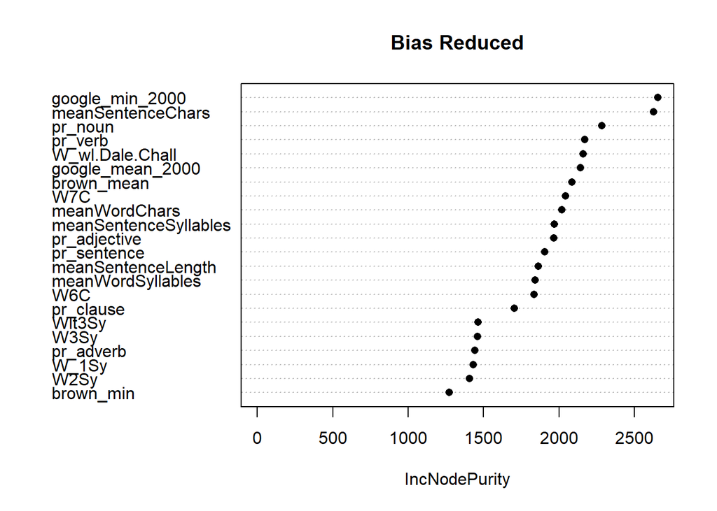

```r
# display feature importance plot
varImpPlot(mod_bias_reduced, main = "Bias Reduced", pch = 16)
```

#### Step 4.2: Without bias reduction

```r
# NOTE: section based very closely on original code
# ---
# Y target feature: text easiness ("ability")
y2 <- BTabilities(BT2)[, "ability"]

# remove NAs
yy2 <- y2[!is.na(y2)]

# return row number, match left to right
mm <- match(names(yy2), rownames(dat$predictors))

# X features for random forest
# instead of having a selected features, we use all features
X2 <- dat$predictors[mm, terms]

# run random forest for non-bias-reduced model
mod_non_bias_reduced <- randomForest(X2, y = yy2, ntree = 1000)

# display feature importance in descending order on node purity
import_non_bias_reduced = round(importance(mod_non_bias_reduced), 2)

# NOTE: new to MB + WS replication
# ---
as.data.frame(import_non_bias_reduced) %>%
  rownames_to_column() %>%
  arrange(-IncNodePurity) %>%
  rename(Feature       = rowname,
         `Node Purity` = IncNodePurity) %>%
  kbl(full_width = T,
      align = "l",
      booktabs = T) %>%
  kable_styling(latex_options = c("repeat_header","scale_down","HOLD_position"), font_size = 12)
```

| Feature | Node Purity |
| --- | --- |
| google_min_2000 | 231941.5 |
| meanSentenceChars | 221967.8 |
| pr_noun | 197819.9 |
| pr_verb | 189685.5 |
| meanSentenceSyllables | 176784.5 |
| google_mean_2000 | 173178.1 |
| W_wl.Dale.Chall | 170164.4 |
| brown_mean | 168664.0 |
| pr_adjective | 167287.7 |
| W7C | 166192.2 |
| meanWordChars | 164323.3 |
| meanSentenceLength | 163457.2 |
| pr_sentence | 159720.4 |
| W6C | 152918.0 |
| meanWordSyllables | 146960.2 |
| pr_clause | 141016.1 |
| Wlt3Sy | 129454.6 |
| pr_adverb | 124764.4 |
| W3Sy | 124195.3 |
| W_1Sy | 121167.9 |
| W2Sy | 119189.1 |
| brown_min | 110476.5 |

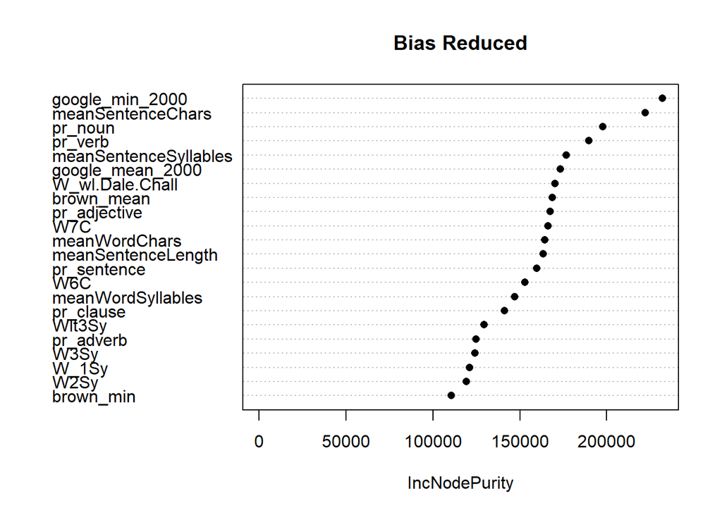

```r
# display feature importance plot
varImpPlot(mod_non_bias_reduced, main = "Bias Reduced", pch = 16)
```

### Step 5. Fit 4 main structured Bradley-Terry models

```r
# NOTE: section based very closely on original code
# ---

# Bradley-Terry 1: control only for baseline FRE score
BT_basic_Flesch <- BTm(player1 = easier, player2 = harder,
                       formula = ~ Flesch[ID], id = "ID",
                       data = job999866covars_chameleons)

# Bradley-Terry 2: control for FRE components (sentence length, word syllables), allowing for reweighting
BT_optimal_Flesch <- BTm(player1 = easier, player2 = harder,
                         formula = ~ meanSentenceLength[ID] + meanWordSyllables[ID],
                         id = "ID", data = job999866covars_chameleons)

# Bradley-Terry 3: control for 3 of 4 top covariates identified from random forest feature selection
BT_basic_RF <- BTm(player1 = easier, player2 = harder,
                   formula = ~ google_min_2000[ID] + meanSentenceChars[ID] + pr_noun[ID],
                   id ="ID", data = job999866covars_chameleons)

# Bradley-Terry 4: control for 4 top covariates identified from random forest feature selection
BT_best <- BTm(player1 = easier, player2 = harder,
               formula = ~ google_min_2000[ID] +  meanSentenceChars[ID] + pr_noun[ID] + meanWordChars[ID],
               id = "ID", data = job999866covars_chameleons)

# save results from four models
model_results <- list(BT_basic_Flesch = BT_basic_Flesch,
                      BT_basic_RF = BT_basic_RF,
                      BT_optimal_Flesch = BT_optimal_Flesch,
                      BT_best = BT_best)
```

### Step 6. Create model results table

Corresponds to **Table 2** in paper.

```r
# NOTE: section remodeled in MB + WS replication to account for retirement of apsrtable package
# ---

# put models in a list
models <- list("FRE Baseline"   = BT_basic_Flesch,
               "FRE Reweight"   = BT_optimal_Flesch,
               "Basic RF Model" = BT_basic_RF,
               "Best Model"     = BT_best)

# specify table formatting
fmt <- list(
       list("raw" = "Num.Obs.", "clean" = "N", "fmt" = 0))

# produce LaTeX table
msummary(models,
         escape = FALSE,
         title = "Table 2. Comparing the Performance of the Structured Models",
         coef_rename = c("Flesch[ID]"               = "FRE",
                        "meanSentenceLength[ID]"    = "meanSentenceLength",
                        "meanWordSyllables[ID]"     = "meanWordSyllables",
                        "google_min_2000[ID]"       = "google_min",
                        "meanSentenceChars[ID]"     = "meanSentenceChars",
                        "pr_noun[ID]"               = "pr_noun",
                        "meanWordChars[ID]"         = "meanWordChars"))
```

Table 2. Comparing the Performance of the Structured Models

|  | FRE Baseline | FRE Reweight | Basic RF Model | Best Model |
| --- | --- | --- | --- | --- |
| FRE | 0.020 |  |  |  |
|  | (0.001) |  |  |  |
| meanSentenceLength |  | -0.062 |  |  |
|  |  | (0.003) |  |  |
| meanWordSyllables |  | -1.773 |  |  |
|  |  | (0.070) |  |  |
| google_min |  |  | 1317.497 | 1336.755 |
|  |  |  | (153.396) | (155.927) |
| meanSentenceChars |  |  | -0.015 | -0.014 |
|  |  |  | (0.001) | (0.001) |
| pr_noun |  |  | 0.505 | 0.390 |
|  |  |  | (0.167) | (0.168) |
| meanWordChars |  |  |  | -0.311 |
|  |  |  |  | (0.024) |
| Num.Obs. | 19430 | 19430 | 19430 | 19430 |
| AIC | 26274.3 | 25923.5 | 25921.0 | 25747.6 |
| BIC | 26282.2 | 25939.2 | 25944.7 | 25779.1 |
| RMSE | 0.49 | 0.49 | 0.49 | 0.49 |

### Step 7. Generate figure comparing authors’ model to FRE

Corresponds to **Figure 1** in paper.

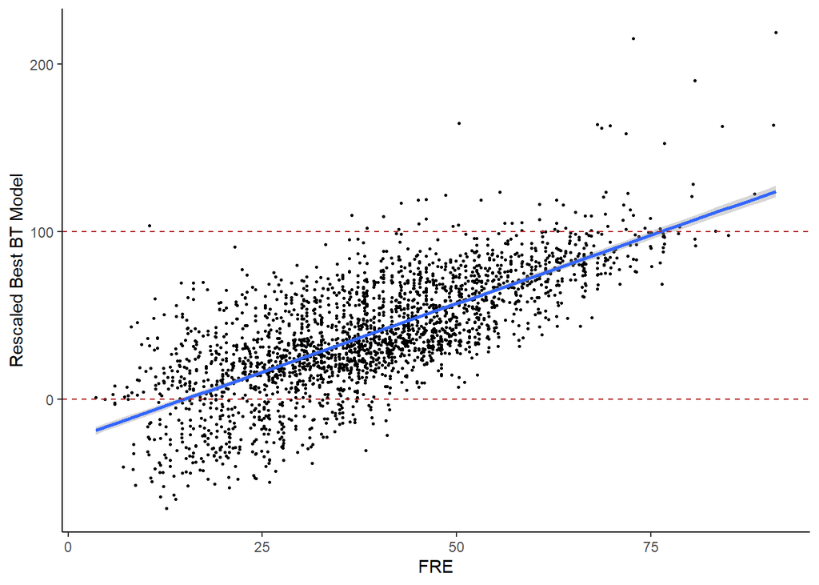

```r
# NOTE: section based entirely on original code
# ---

# get FRE scores for the snippets
dat <- job999866covars_chameleons
FRE <- dat$predictors$Flesch

names(FRE) <- rownames(dat$predictors)

# get lambdas from best fitting model
main_lambdas <- BTabilities(BT_best)[,"ability"]

# rescale lambdas to the 0-100 space correctly
rescaled_lambdas <- 226.06927 + 57.93899 * main_lambdas

# check that they are matched up
m <- match(names(FRE), names(rescaled_lambdas)) ## they are matched up

# produce plot
ggplot(data.frame(FRE = FRE, rslambda = rescaled_lambdas), aes(x = FRE, y = rslambda)) +
    geom_point(size = .6) +
    labs(y = "Rescaled Best BT Model") +
    geom_smooth(method = "lm", se = TRUE) +
    geom_hline(yintercept = c(0, 100), linetype = "dashed", color = "firebrick") +
    theme(axis.text.x = element_text(size = 5),
          axis.text.y = element_text(size = 5)) +
    theme_classic()
```